# Validating smoothbp against brms and mcp

## Why this vignette exists

`smoothbp` is a bespoke Metropolis-within-Gibbs sampler for Bayesian hierarchical piecewise regression with **multiple** logistic-smoothed change-points. The recovery tests are a self-consistency check — simulator and likelihood share the same code path. To trust the package one also wants to see that it agrees with an independent implementation. `brms` (via Stan) is the natural reference for fitting the same generative model via NUTS on a custom non-linear formula. `mcp` (via JAGS) is the closest specialist competitor and provides a complementary perspective: it fits **hard** (sharp) change-points rather than the logistic-smoothed transition that `smoothbp` uses.

Four scenarios are compared below:

1. **Baseline (random intercept)** — a random intercept on `b0` with all structural parameters scalar (`~ 1`). Compared against **brms**.
2. **Covariate on omega** — `omega ~ 1 + treatment`. Compared against **brms**.
3. **Hard vs smooth change-point** — single change-point, fixed effects only. Compared against **mcp**.
4. **Multi-breakpoint** — two true change-points, single group / fixed effects; smoothbp vs brms, showing overlapping posterior distributions.

### One important practical note before we start

When the change-point parameter `omega` drifts outside the range of the time variable, the smoothing term collapses and `delta1` becomes effectively unidentified. NUTS chains that initialise in that region can get stuck there for the entire run, producing an artificially multimodal posterior that has nothing to do with the data. The clean fix is to bound `omega` above at `max(tau)` in both samplers, and to initialise brms chains near the prior mean (which is what smoothbp does internally). Both fixes applied below.

```r
library(smoothbp)
library(posterior)
library(ggplot2)
library(dplyr)
library(tidyr)

have_brms <- requireNamespace("brms", quietly = TRUE) && NOT_CRAN
if (!have_brms && NOT_CRAN) {
  message("brms not installed -- install.packages('brms') to render the comparison.")
}

have_mcp <- requireNamespace("mcp",   quietly = TRUE) &&
            requireNamespace("rjags", quietly = TRUE) && NOT_CRAN
if (!have_mcp && NOT_CRAN) {
  message("mcp or rjags not installed -- install JAGS then install.packages('mcp') ",
          "to render the mcp comparison.")
}
```

# Scenario 1: Baseline model (random intercept, scalar parameters)

## Simulate one dataset

```r
set.seed(31)
dat <- simulate_smoothbp(
  n_subj = 25, n_obs = 10,
  b0 = 5.0, b1 = -0.4, delta = 1.4,
  omega = 3.2, rho = 4.0,
  sigma = 0.4, sigma_u = 0.7,
  seed = 31L
)
true_params(dat)
```

```
#> Data-generating parameters:
#>   b0:        5
#>   b1:        -0.4
#>   sigma:     0.4
#>   sigma_u:   0.7
#>   seed:      31
#>   omega[1]:  3.2
#>   delta[1]:  1.4
#>   rho[1]:    4
```

## Fit with smoothbp

```r
t0 <- Sys.time()
fit_sbp <- smoothbp(
  formula = y ~ tau,
  b0      = ~ 1 + (1 | subject),
  b1      = ~ 1,
  deltas  = list(~ 1),
  omega   = list(~ 1),
  rho     = list(~ 1),
  data    = dat,
  priors  = smoothbp_priors(
    b0      = prior_normal(0, 10),
    b1      = prior_normal(0, 2),
    omega   = list(prior_normal(3, 2, lb = 0, ub = max(dat$tau))),
    rho     = list(prior_normal(3, 2, lb = 0)),
    # Diffuse variance priors, matched (as closely as the two parameterisations
    # allow) to the brms half-t below. smoothbp's variance update is conjugate,
    # so the family must be inverse-gamma; (0.001, 0.001) makes it effectively
    # non-informative for the well-identified residual SD.
    sigma   = prior_invgamma(0.001, 0.001),
    sigma_u = prior_invgamma(0.001, 0.001)
  ),
  chains  = 4L, iter = 2000L, warmup = 1000L,
  seed    = 31L, .verbose = FALSE
)
time_sbp <- as.numeric(difftime(Sys.time(), t0, units = "secs"))
```

## Fit with brms (Stan / NUTS)

```r
suppressPackageStartupMessages(library(brms))

# Note: brms requires named non-linear parameters in its formula.  Here `b2`
# is the brms-side name for the slope-change parameter; it corresponds to
# `delta` (delta_1) in smoothbp's parameterisation.
bf_smoothed <- brms::bf(
  y ~ b0 + b1 * (tau - omega) +
        b2 * (tau - omega) / (1 + exp(-(tau - omega) * rho)),
  b0 ~ 1 + (1 | subject),
  b1 ~ 1, b2 ~ 1, omega ~ 1, rho ~ 1,  # b2 = smoothbp's delta_1
  nl = TRUE
)

# brms::prior() captures arguments by non-standard evaluation, so
# `ub = max(dat$tau)` would be embedded literally in the generated Stan
# code. Pre-compute the value and pass it via prior_string() which uses
# standard evaluation and accepts numeric bounds.
ub_omega <- max(dat$tau)

priors_brms <- c(
  brms::prior(normal(0, 10), nlpar = "b0"),
  brms::prior(normal(0, 2),  nlpar = "b1"),
  brms::prior(normal(0, 2),  nlpar = "b2"),
  brms::prior_string("normal(3, 2)", nlpar = "omega",
                     lb = 0, ub = ub_omega),
  brms::prior(normal(3, 2),  nlpar = "rho",   lb = 0),
  # Diffuse variance priors, matched to smoothbp's near-non-informative
  # inverse-gamma above. A wide half-t leaves the residual SD likelihood-
  # dominated; the group SD remains weakly identified with only 25 subjects.
  # In a non-linear model the group SD belongs to its nlpar, so `nlpar = "b0"`
  # is required (a bare `class = "sd"` matches no parameter).
  brms::prior(student_t(3, 0, 10), class = "sigma"),
  brms::prior(student_t(3, 0, 10), class = "sd", nlpar = "b0")
)

# Initialise every chain near the prior mean.  Without this, Stan's default
# uniform-on-(-2, 2) initialisation lands some chains in the unidentifiable
# omega > max(tau) trap and they never escape.
init_fun <- function() list(
  b_b0    = array(rnorm(1, 5, 1)),
  b_b1    = array(rnorm(1, 0, 0.3)),
  b_b2    = array(rnorm(1, 0, 0.3)),
  b_omega = array(rnorm(1, 3, 0.3)),
  b_rho   = array(rnorm(1, 3, 0.5))
)

t0 <- Sys.time()
fit_brms <- brms::brm(
  bf_smoothed,
  data    = dat,
  prior   = priors_brms,
  chains  = 4, iter = 2000, warmup = 1000,
  seed    = 31, refresh = 0,
  init    = init_fun,
  control = list(adapt_delta = 0.95)
)
time_brms <- as.numeric(difftime(Sys.time(), t0, units = "secs"))
```

## Did brms converge?

```r
sbp_names <- c(
  "b0_(Intercept)", "b1_(Intercept)", "delta1_(Intercept)",
  "omega1_(Intercept)", "rho1_(Intercept)",
  "sigma", "sigma_u"
)
brms_names <- c(
  "b_b0_Intercept", "b_b1_Intercept", "b_b2_Intercept",
  "b_omega_Intercept", "b_rho_Intercept",
  "sigma", "sd_subject__b0_Intercept"
)

posterior::summarise_draws(
  posterior::as_draws_df(fit_brms), rhat, ess_bulk
) %>%
  dplyr::filter(variable %in% brms_names) %>%
  dplyr::transmute(parameter = sbp_names[match(variable, brms_names)],
                   rhat, ess_bulk) %>%
  knitr::kable(digits = 3,
               caption = "brms convergence on population-level parameters.")
```

brms convergence on population-level parameters.

| parameter | rhat | ess_bulk |
| --- | --- | --- |
| b0_(Intercept) | 1.008 | 466.108 |
| b1_(Intercept) | 1.001 | 2029.368 |
| delta1_(Intercept) | 1.002 | 2151.662 |
| omega1_(Intercept) | 1.001 | 2784.065 |
| rho1_(Intercept) | 1.000 | 2812.279 |
| sigma_u | 1.019 | 393.268 |
| sigma | 1.002 | 2915.035 |

If any `rhat` exceeds 1.05, brms has not mixed and the comparison below is contaminated; do not interpret disagreements as smoothbp errors. With the bounded `omega` prior and the seeded `init_fun`, all four chains should land in the same basin.

## Compare posterior summaries

```r
sbp_draws  <- posterior::as_draws_df(fit_sbp$draws)[, sbp_names]
brms_draws <- as.data.frame(posterior::as_draws_df(fit_brms))[, brms_names]
colnames(brms_draws) <- sbp_names

draws_long <- dplyr::bind_rows(
  tidyr::pivot_longer(sbp_draws,  cols = dplyr::everything(),
                      names_to = "parameter", values_to = "value") %>%
    dplyr::mutate(package = "smoothbp"),
  tidyr::pivot_longer(brms_draws, cols = dplyr::everything(),
                      names_to = "parameter", values_to = "value") %>%
    dplyr::mutate(package = "brms")
)

draws_long %>%
  dplyr::group_by(parameter, package) %>%
  dplyr::summarise(
    mean = mean(value),
    sd   = sd(value),
    q025 = quantile(value, 0.025),
    q975 = quantile(value, 0.975),
    .groups = "drop"
  ) %>%
  tidyr::pivot_wider(
    names_from  = package,
    values_from = c(mean, sd, q025, q975),
    names_glue  = "{package}_{.value}"
  ) %>%
  dplyr::mutate(
    delta_mean_pct = 100 * abs(smoothbp_mean - brms_mean) /
                       (abs(brms_mean) + 1e-8)
  ) %>%
  knitr::kable(digits = 3,
               caption = "Posterior summaries for both packages.")
```

Posterior summaries for both packages.

| parameter | brms_mean | smoothbp_mean | brms_sd | smoothbp_sd | brms_q025 | smoothbp_q025 | brms_q975 | smoothbp_q975 | delta_mean_pct |
| --- | --- | --- | --- | --- | --- | --- | --- | --- | --- |
| b0_(Intercept) | 5.045 | 5.048 | 0.154 | 0.140 | 4.730 | 4.752 | 5.330 | 5.317 | 0.052 |
| b1_(Intercept) | -0.335 | -0.332 | 0.036 | 0.035 | -0.407 | -0.401 | -0.264 | -0.261 | 0.719 |
| delta1_(Intercept) | 1.312 | 1.309 | 0.056 | 0.055 | 1.200 | 1.201 | 1.420 | 1.418 | 0.209 |
| omega1_(Intercept) | 3.257 | 3.260 | 0.080 | 0.079 | 3.104 | 3.113 | 3.415 | 3.420 | 0.105 |
| rho1_(Intercept) | 3.972 | 4.005 | 1.278 | 1.349 | 2.066 | 2.046 | 7.035 | 7.024 | 0.820 |
| sigma | 0.395 | 0.395 | 0.020 | 0.019 | 0.360 | 0.360 | 0.436 | 0.435 | 0.165 |
| sigma_u | 0.661 | 0.638 | 0.110 | 0.101 | 0.482 | 0.473 | 0.910 | 0.874 | 3.365 |

## Overlaid marginal posteriors

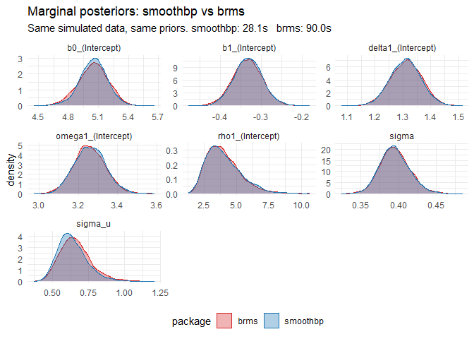

```r
p_overlay <- ggplot(draws_long, aes(x = value, fill = package, colour = package)) +
  geom_density(alpha = 0.35) +
  facet_wrap(~ parameter, scales = "free", ncol = 3) +
  scale_fill_manual(values  = c(smoothbp = "#1f77b4", brms = "#d62728")) +
  scale_colour_manual(values = c(smoothbp = "#1f77b4", brms = "#d62728")) +
  labs(
    title    = "Marginal posteriors: smoothbp vs brms",
    subtitle = sprintf(
      "Same simulated data, same priors. smoothbp: %.1fs   brms: %.1fs",
      time_sbp, time_brms
    ),
    x = NULL, y = "density"
  ) +
  theme_minimal(base_size = 11) +
  theme(legend.position = "bottom")
p_overlay
```

## Distributional agreement (1-Wasserstein)

Agreement of posterior *means* is necessary but not sufficient: two posteriors can share a mean yet differ in spread or shape. We therefore compare the full marginal distributions with the 1-Wasserstein (earth-mover’s) distance, standardised by the pooled posterior SD so it is scale-free. As a Monte Carlo reference we also report the distance between two independent smoothbp runs (seeds 31 and 32); cross-package distances of the same order as this within-sampler reference indicate marginals that are indistinguishable up to Monte Carlo error.

All priors, including the variance components, are matched as closely as the two parameterisations allow. smoothbp’s variance update is conjugate, so its family must be inverse-gamma; here it is made near-non-informative (`prior_invgamma(0.001, 0.001)`) and brms is given a correspondingly wide half-t. Under matched diffuse priors the residual SD `sigma` is likelihood-dominated and should agree to Monte Carlo error. The random-effect SD `sigma_u` is only weakly identified by 25 subjects, so any small residual cross-package difference there reflects that weak identification (and the unavoidable inverse-gamma-versus-half-t tail difference) rather than a discrepancy between the samplers.

```r
# standardised 1-D 1-Wasserstein distance between two samples
w1_std <- function(x, y) {
  p  <- ppoints(1000)
  qx <- quantile(x, p, names = FALSE, type = 8)
  qy <- quantile(y, p, names = FALSE, type = 8)
  mean(abs(qx - qy)) / stats::sd(c(x, y))
}

# second smoothbp run (different seed) as a within-sampler Monte Carlo reference
fit_sbp_b <- smoothbp(
  formula = y ~ tau,
  b0      = ~ 1 + (1 | subject),
  b1      = ~ 1,
  deltas  = list(~ 1),
  omega   = list(~ 1),
  rho     = list(~ 1),
  data    = dat,
  priors  = smoothbp_priors(
    b0      = prior_normal(0, 10),
    b1      = prior_normal(0, 2),
    omega   = list(prior_normal(3, 2, lb = 0, ub = max(dat$tau))),
    rho     = list(prior_normal(3, 2, lb = 0)),
    sigma   = prior_invgamma(0.001, 0.001),
    sigma_u = prior_invgamma(0.001, 0.001)
  ),
  chains  = 4L, iter = 2000L, warmup = 1000L,
  seed    = 32L, .verbose = FALSE
)

sbp_a  <- posterior::as_draws_df(fit_sbp$draws)[, sbp_names]
sbp_b  <- posterior::as_draws_df(fit_sbp_b$draws)[, sbp_names]
brms_w <- as.data.frame(posterior::as_draws_df(fit_brms))[, brms_names]
colnames(brms_w) <- sbp_names

data.frame(
  parameter = sbp_names,
  W1_cross  = vapply(sbp_names, function(nm) w1_std(sbp_a[[nm]], brms_w[[nm]]), numeric(1)),
  W1_null   = vapply(sbp_names, function(nm) w1_std(sbp_a[[nm]], sbp_b[[nm]]),  numeric(1)),
  row.names = NULL
) |>
  knitr::kable(digits = 3,
    caption = "Standardised 1-Wasserstein distance (pooled-SD units): smoothbp vs
               brms (W1_cross) and a within-sampler reference from two smoothbp
               seeds (W1_null). Cross comparable to null => indistinguishable up
               to Monte Carlo error.")
```

Standardised 1-Wasserstein distance (pooled-SD units): smoothbp vs brms (W1_cross) and a within-sampler reference from two smoothbp seeds (W1_null). Cross comparable to null => indistinguishable up to Monte Carlo error.

| parameter | W1_cross | W1_null |
| --- | --- | --- |
| b0_(Intercept) | 0.086 | 0.068 |
| b1_(Intercept) | 0.068 | 0.072 |
| delta1_(Intercept) | 0.050 | 0.031 |
| omega1_(Intercept) | 0.046 | 0.076 |
| rho1_(Intercept) | 0.042 | 0.053 |
| sigma | 0.037 | 0.034 |
| sigma_u | 0.210 | 0.017 |

To export the overlay figure for the manuscript, run (outside CRAN):

```r
ggplot2::ggsave("figure_overlay_s1.png", p_overlay,
                width = 7, height = 5, dpi = 150)
```

## Effective sample size per second

```r
ess_sbp  <- posterior::summarise_draws(fit_sbp$draws, ess_bulk) %>%
  dplyr::filter(variable %in% sbp_names) %>%
  dplyr::transmute(parameter = variable,
                   smoothbp_ess_per_sec = ess_bulk / time_sbp)

ess_brms <- posterior::summarise_draws(
  posterior::as_draws_df(fit_brms), ess_bulk
) %>%
  dplyr::filter(variable %in% brms_names) %>%
  dplyr::mutate(parameter = sbp_names[match(variable, brms_names)]) %>%
  dplyr::transmute(parameter, brms_ess_per_sec = ess_bulk / time_brms)

dplyr::full_join(ess_sbp, ess_brms, by = "parameter") %>%
  knitr::kable(digits = 1,
               caption = "Bulk ESS / second by package and parameter.")
```

Bulk ESS / second by package and parameter.

| parameter | smoothbp_ess_per_sec | brms_ess_per_sec |
| --- | --- | --- |
| b0_(Intercept) | 3.5 | 5.2 |
| b1_(Intercept) | 27.9 | 22.5 |
| delta1_(Intercept) | 84.8 | 23.9 |
| omega1_(Intercept) | 14.3 | 30.9 |
| rho1_(Intercept) | 29.3 | 31.2 |
| sigma | 119.2 | 32.4 |
| sigma_u | 70.5 | 4.4 |

```r
data.frame(
  package     = c("smoothbp", "brms (Stan/NUTS)"),
  wall_clock_s = round(c(time_sbp, time_brms), 1),
  speedup      = c(sprintf("%.0fx faster", time_brms / time_sbp), "reference")
) |>
  knitr::kable(col.names = c("Package", "Wall-clock (s)", "Relative speed"),
               caption   = "Scenario 1 wall-clock time. Single run on the same machine.")
```

Scenario 1 wall-clock time. Single run on the same machine.

| Package | Wall-clock (s) | Relative speed |
| --- | --- | --- |
| smoothbp | 28.1 | 3x faster |
| brms (Stan/NUTS) | 90.0 | reference |

# Scenario 2: Covariate on omega

This scenario exercises the **HMC-within-Gibbs** sampler path that is activated when a non-linear parameter (`omega` or `rho`) has two or more coefficients. Here `omega ~ 1 + treatment` gives a group-specific change-point location.

## Simulate data with treatment effect on omega

```r
set.seed(8147)

n_subj   <- 30
n_obs    <- 10
tau_range <- c(0, 6)

b0_true      <- 5.0
b1_true      <- -0.4
delta_true   <- 1.4
omega_int    <- 3.2
omega_trt    <- -0.8
rho_true     <- 4.0
sigma_true   <- 0.4
sigma_u_true <- 0.7

treatment <- rep(c(0, 1), each = n_subj / 2)
u_j <- rnorm(n_subj, 0, sigma_u_true)
.sigmoid <- function(x) 1 / (1 + exp(-x))

rows <- vector("list", n_subj)
for (j in seq_len(n_subj)) {
  tau_j   <- seq(tau_range[1], tau_range[2], length.out = n_obs)
  omega_j <- omega_int + omega_trt * treatment[j]
  d_j     <- tau_j - omega_j
  s_j     <- .sigmoid(d_j * rho_true)
  mu_j    <- (b0_true + u_j[j]) + b1_true * d_j + delta_true * d_j * s_j
  rows[[j]] <- data.frame(
    subject   = factor(j),
    tau       = tau_j,
    treatment = treatment[j],
    y         = mu_j + rnorm(n_obs, 0, sigma_true)
  )
}
dat_cov <- do.call(rbind, rows)

cat(sprintf("True omega: intercept = %.1f, treatment effect = %.1f\n",
            omega_int, omega_trt))
```

```
#> True omega: intercept = 3.2, treatment effect = -0.8
```

```r
cat(sprintf("  Control  (treatment = 0): omega = %.1f\n", omega_int))
```

```
#>   Control  (treatment = 0): omega = 3.2
```

```r
cat(sprintf("  Treated  (treatment = 1): omega = %.1f\n", omega_int + omega_trt))
```

```
#>   Treated  (treatment = 1): omega = 2.4
```

## Fit with smoothbp

```r
t0 <- Sys.time()
fit_sbp_cov <- smoothbp(
  formula = y ~ tau,
  b0      = ~ 1 + (1 | subject),
  b1      = ~ 1,
  deltas  = list(~ 1),
  omega   = list(~ 1 + treatment),
  rho     = list(~ 1),
  data    = dat_cov,
  priors  = smoothbp_priors(
    b0    = prior_normal(0, 10),
    b1    = prior_normal(0, 2),
    omega = list(list(
      "(Intercept)" = prior_normal(3, 2, lb = 0, ub = max(dat_cov$tau)),
      "treatment"   = prior_normal(0, 2)
    )),
    rho   = list(prior_normal(3, 2, lb = 0))
  ),
  chains  = 4L, iter = 2000L, warmup = 1000L,
  seed    = 8147L, .verbose = FALSE
)
time_sbp_cov <- as.numeric(difftime(Sys.time(), t0, units = "secs"))
```

## Fit with brms

```r
bf_cov <- brms::bf(
  y ~ b0 + b1 * (tau - omega) +
        b2 * (tau - omega) / (1 + exp(-(tau - omega) * rho)),
  b0    ~ 1 + (1 | subject),
  b1    ~ 1,
  b2    ~ 1,
  omega ~ 1 + treatment,
  rho   ~ 1,
  nl = TRUE
)

priors_brms_cov <- c(
  brms::prior(normal(0, 10), nlpar = "b0"),
  brms::prior(normal(0, 2),  nlpar = "b1"),
  brms::prior(normal(0, 2),  nlpar = "b2"),
  brms::prior_string("normal(3, 2)", nlpar = "omega", coef = "Intercept"),
  brms::prior(normal(0, 2),  nlpar = "omega", coef = "treatment"),
  brms::prior(normal(3, 2),  nlpar = "rho", lb = 0)
)

init_fun_cov <- function() list(
  b_b0    = array(rnorm(1, 5, 1)),
  b_b1    = array(rnorm(1, 0, 0.3)),
  b_b2    = array(rnorm(1, 0, 0.3)),
  b_omega = array(c(rnorm(1, 3, 0.3), rnorm(1, -0.5, 0.3))),
  b_rho   = array(rnorm(1, 3, 0.5))
)

t0 <- Sys.time()
fit_brms_cov <- brms::brm(
  bf_cov,
  data    = dat_cov,
  prior   = priors_brms_cov,
  chains  = 4, iter = 2000, warmup = 1000,
  seed    = 8147, refresh = 0,
  init    = init_fun_cov,
  control = list(adapt_delta = 0.95)
)
time_brms_cov <- as.numeric(difftime(Sys.time(), t0, units = "secs"))
```

## Compare posteriors

```r
sbp_names_cov <- c(
  "b0_(Intercept)", "b1_(Intercept)", "delta1_(Intercept)",
  "omega1_(Intercept)", "omega1_treatment",
  "rho1_(Intercept)", "sigma", "sigma_u"
)
brms_names_cov <- c(
  "b_b0_Intercept", "b_b1_Intercept", "b_b2_Intercept",
  "b_omega_Intercept", "b_omega_treatment",
  "b_rho_Intercept", "sigma", "sd_subject__b0_Intercept"
)

sbp_draws_cov  <- posterior::as_draws_df(fit_sbp_cov$draws)[, sbp_names_cov]
brms_draws_cov <- as.data.frame(
  posterior::as_draws_df(fit_brms_cov)
)[, brms_names_cov]
colnames(brms_draws_cov) <- sbp_names_cov

draws_long_cov <- dplyr::bind_rows(
  tidyr::pivot_longer(sbp_draws_cov, cols = dplyr::everything(),
                      names_to = "parameter", values_to = "value") %>%
    dplyr::mutate(package = "smoothbp"),
  tidyr::pivot_longer(brms_draws_cov, cols = dplyr::everything(),
                      names_to = "parameter", values_to = "value") %>%
    dplyr::mutate(package = "brms")
)

draws_long_cov %>%
  dplyr::group_by(parameter, package) %>%
  dplyr::summarise(
    mean = mean(value),
    sd   = sd(value),
    q025 = quantile(value, 0.025),
    q975 = quantile(value, 0.975),
    .groups = "drop"
  ) %>%
  tidyr::pivot_wider(
    names_from  = package,
    values_from = c(mean, sd, q025, q975),
    names_glue  = "{package}_{.value}"
  ) %>%
  dplyr::mutate(
    delta_mean_pct = 100 * abs(smoothbp_mean - brms_mean) /
                       (abs(brms_mean) + 1e-8)
  ) %>%
  knitr::kable(digits = 3,
               caption = "Posterior summaries: omega ~ 1 + treatment.")
```

Posterior summaries: omega ~ 1 + treatment.

| parameter | brms_mean | smoothbp_mean | brms_sd | smoothbp_sd | brms_q025 | smoothbp_q025 | brms_q975 | smoothbp_q975 | delta_mean_pct |
| --- | --- | --- | --- | --- | --- | --- | --- | --- | --- |
| b0_(Intercept) | 5.122 | 5.104 | 0.155 | 0.166 | 4.816 | 4.765 | 5.425 | 5.407 | 0.369 |
| b1_(Intercept) | -0.374 | -0.377 | 0.042 | 0.043 | -0.460 | -0.461 | -0.297 | -0.293 | 0.744 |
| delta1_(Intercept) | 1.336 | 1.338 | 0.054 | 0.055 | 1.231 | 1.232 | 1.444 | 1.448 | 0.159 |
| omega1_(Intercept) | 3.130 | 3.126 | 0.083 | 0.083 | 2.965 | 2.968 | 3.291 | 3.296 | 0.143 |
| omega1_treatment | -0.742 | -0.742 | 0.074 | 0.073 | -0.890 | -0.884 | -0.600 | -0.602 | 0.112 |
| rho1_(Intercept) | 3.686 | 3.804 | 1.139 | 1.184 | 2.066 | 2.168 | 6.419 | 6.627 | 3.204 |
| sigma | 0.420 | 0.426 | 0.018 | 0.018 | 0.387 | 0.393 | 0.457 | 0.465 | 1.393 |
| sigma_u | 0.755 | 0.769 | 0.105 | 0.105 | 0.580 | 0.599 | 0.987 | 1.004 | 1.856 |

## Overlaid marginal posteriors (covariate model)

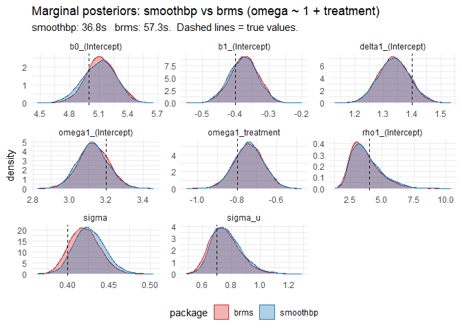

```r
true_vals_cov <- data.frame(
  parameter = c("b0_(Intercept)", "b1_(Intercept)", "delta1_(Intercept)",
                 "omega1_(Intercept)", "omega1_treatment",
                 "rho1_(Intercept)", "sigma", "sigma_u"),
  true_value = c(b0_true, b1_true, delta_true,
                  omega_int, omega_trt, rho_true, sigma_true, sigma_u_true)
)

ggplot(draws_long_cov, aes(x = value, fill = package, colour = package)) +
  geom_density(alpha = 0.35) +
  geom_vline(data = true_vals_cov, aes(xintercept = true_value),
             linetype = "dashed", linewidth = 0.5) +
  facet_wrap(~ parameter, scales = "free", ncol = 3) +
  scale_fill_manual(values  = c(smoothbp = "#1f77b4", brms = "#d62728")) +
  scale_colour_manual(values = c(smoothbp = "#1f77b4", brms = "#d62728")) +
  labs(
    title    = "Marginal posteriors: smoothbp vs brms (omega ~ 1 + treatment)",
    subtitle = sprintf(
      "smoothbp: %.1fs   brms: %.1fs.  Dashed lines = true values.",
      time_sbp_cov, time_brms_cov
    ),
    x = NULL, y = "density"
  ) +
  theme_minimal(base_size = 11) +
  theme(legend.position = "bottom")
```

## Effective sample size per second (covariate model)

```r
ess_sbp_cov  <- posterior::summarise_draws(fit_sbp_cov$draws, ess_bulk) %>%
  dplyr::filter(variable %in% sbp_names_cov) %>%
  dplyr::transmute(parameter = variable,
                   smoothbp_ess_per_sec = ess_bulk / time_sbp_cov)

ess_brms_cov <- posterior::summarise_draws(
  posterior::as_draws_df(fit_brms_cov), ess_bulk
) %>%
  dplyr::filter(variable %in% brms_names_cov) %>%
  dplyr::mutate(parameter = sbp_names_cov[match(variable, brms_names_cov)]) %>%
  dplyr::transmute(parameter, brms_ess_per_sec = ess_bulk / time_brms_cov)

dplyr::full_join(ess_sbp_cov, ess_brms_cov, by = "parameter") %>%
  knitr::kable(digits = 1,
               caption = "Bulk ESS / second by package and parameter (covariate model).")
```

Bulk ESS / second by package and parameter (covariate model).

| parameter | smoothbp_ess_per_sec | brms_ess_per_sec |
| --- | --- | --- |
| b0_(Intercept) | 1.6 | 6.2 |
| b1_(Intercept) | 21.9 | 28.9 |
| delta1_(Intercept) | 60.8 | 33.4 |
| omega1_(Intercept) | 16.0 | 33.0 |
| omega1_treatment | 91.8 | 45.7 |
| rho1_(Intercept) | 24.8 | 45.5 |
| sigma | 90.2 | 61.8 |
| sigma_u | 37.3 | 9.5 |

```r
data.frame(
  package      = c("smoothbp", "brms (Stan/NUTS)"),
  wall_clock_s = round(c(time_sbp_cov, time_brms_cov), 1),
  speedup       = c(sprintf("%.0fx faster", time_brms_cov / time_sbp_cov), "reference")
) |>
  knitr::kable(col.names = c("Package", "Wall-clock (s)", "Relative speed"),
               caption   = "Scenario 2 wall-clock time. Covariate-on-omega model.")
```

Scenario 2 wall-clock time. Covariate-on-omega model.

| Package | Wall-clock (s) | Relative speed |
| --- | --- | --- |
| smoothbp | 36.8 | 2x faster |
| brms (Stan/NUTS) | 57.3 | reference |

# Scenario 3: Hard vs smooth change-point — comparison with mcp

`mcp` (Lindeløv, 2020) is the closest R package to `smoothbp` in terms of use case: Bayesian piecewise regression with flexible segment specification and a formula interface. The fundamental modelling difference is that `mcp` uses a **hard** (step-function) change-point — the trajectory makes an instantaneous kink at `cp_1` — while `smoothbp` uses a **logistic sigmoid** to smooth the transition, with the sharpness parameter `rho` controlling how abrupt it is. As `rho -> infinity` the smooth transition converges to the hard kink, so on data generated with large `rho` the two approaches should give consistent estimates of the change-point location and slopes.

## Parameterisation note

`mcp`’s two-segment joined-slope model has parameters:

| mcp parameter | smoothbp equivalent |
| --- | --- |
| `cp_1` | `omega_(Intercept)` (change-point location) |
| `time_1` | `b1_(Intercept)` (pre-change slope) |
| `time_2` | `b1_(Intercept) + delta1_(Intercept)` (post-change slope) |
| `int_1` | `b0_(Intercept) - b1 * omega` (level at tau = 0, not at change-point) |
| `sigma_1` | `sigma` |

The intercept-level parameters are not directly comparable because `smoothbp` anchors `b0` at the change-point while `mcp` anchors `int_1` at `tau = 0`. The slopes and change-point location are directly comparable.

## Simulate fixed-effects data

```r
set.seed(5501)

dat_mcp <- simulate_smoothbp(
  n_subj    = 1,
  n_obs     = 150,
  b0        = 5.0,
  b1        = -0.4,
  delta     =  1.4,
  omega     =  3.2,
  rho       =  5.0,   # moderately sharp — should agree well with mcp
  sigma     =  0.4,
  sigma_u   =  0.0,   # no random effects
  tau_range = c(0, 6),
  seed      = 5501L
)

# mcp expects a plain data.frame without the factor column
dat_mcp_plain <- data.frame(tau = dat_mcp$tau, y = dat_mcp$y)

cat(sprintf("n = %d  |  true omega = 3.2  |  true b1 = -0.4  |  true delta1 = 1.4\n",
            nrow(dat_mcp_plain)))
```

```
#> n = 150  |  true omega = 3.2  |  true b1 = -0.4  |  true delta1 = 1.4
```

```r
t0 <- Sys.time()
fit_sbp_mcp <- smoothbp(
  formula = y ~ tau,
  b0      = ~ 1,
  b1      = ~ 1,
  deltas  = list(~ 1),
  omega   = list(~ 1),
  rho     = list(fixed(100)), # Use fixed() to specify a sharp, hard kink
  data    = dat_mcp,
  priors  = smoothbp_priors(
    b0    = prior_normal(0, 10),
    b1    = prior_normal(0, 2),
    omega = list(prior_normal(3, 2, lb = 0, ub = max(dat_mcp$tau)))
  ),
  chains = 4L, iter = 2000L, warmup = 1000L,
  seed = 5501L, .verbose = FALSE
)
time_sbp_mcp <- as.numeric(difftime(Sys.time(), t0, units = "secs"))
cat(sprintf("smoothbp: %.1f s\n", time_sbp_mcp))
```

```
#> smoothbp: 9.8 s
```

## Fit with mcp (hard change-point)

```r
# Two-segment joined-slope model: the natural mcp equivalent
model_mcp <- list(
  y ~ 1 + tau,   # segment 1: intercept + pre-change slope
  ~ 0 + tau      # segment 2: joined at cp_1, post-change slope
)

# Restrict cp_1 to the observed time range, matching the smoothbp bound
prior_mcp <- list(cp_1 = "dunif(0, 6)")
set.seed(5501)
t0 <- Sys.time()
fit_mcp <- mcp::mcp(
  model_mcp,
  data  = dat_mcp_plain,
  prior = prior_mcp,
  par_x = "tau",
  chains = 4L, iter = 2000L, adapt = 1000L,
)
time_mcp <- as.numeric(difftime(Sys.time(), t0, units = "secs"))
cat(sprintf("mcp: %.1f s\n", time_mcp))
```

## Compare posteriors

The critical comparison is on `omega` / `cp_1` (change-point location) and the two slopes. The post-change slope from mcp (`time_2`) is equivalent to `b1 + delta1` in smoothbp.

```r
sbp_sum_mcp <- posterior::summarise_draws(fit_sbp_mcp$draws) |>
  dplyr::filter(variable %in% c("b1_(Intercept)", "delta1_(Intercept)", "omega1_(Intercept)",
                               "rho1_(Intercept)", "sigma"))

mcp_sum <- summary(fit_mcp) |>
  dplyr::filter(name %in% c("cp_1", "int_1", "tau_1", "tau_2", "sigma_1"))
```

```
#> Family: gaussian(link = 'identity')
#> Iterations: 8000 from 4 chains.
#> Segments:
#>   1: y ~ 1 + tau
#>   2: y ~ 1 ~ 0 + tau
#>
#> Population-level parameters:
#>     name  mean lower upper Rhat n.eff
#>     cp_1  3.06  2.87  3.23    1   495
#>    int_1  6.25  6.07  6.41    1   335
#>  sigma_1  0.39  0.35  0.44    1  4611
#>    tau_1 -0.41 -0.51 -0.32    1   219
#>    tau_2  0.92  0.81  1.01    1   905
```

```r
# Compute post-change slope from smoothbp draws for direct comparison
dm_sbp_mcp <- posterior::as_draws_matrix(fit_sbp_mcp$draws)
post_slope <- as.numeric(dm_sbp_mcp[, "b1_(Intercept)"] +
                           dm_sbp_mcp[, "delta1_(Intercept)"])

comparison_mcp <- data.frame(
  parameter          = c("omega / cp_1",
                          "b1 / time_1 (pre-change slope)",
                          "b1+delta1 / time_2 (post-change slope)",
                          "sigma"),
  truth              = c(3.2, -0.4, -0.4 + 1.4, 0.4),
  sbp_mean           = c(
    sbp_sum_mcp$mean[sbp_sum_mcp$variable == "omega1_(Intercept)"],
    sbp_sum_mcp$mean[sbp_sum_mcp$variable == "b1_(Intercept)"],
    mean(post_slope),
    sbp_sum_mcp$mean[sbp_sum_mcp$variable == "sigma"]
  ),
  sbp_lo             = c(
    sbp_sum_mcp$q2.5[sbp_sum_mcp$variable == "omega1_(Intercept)"],
    sbp_sum_mcp$q2.5[sbp_sum_mcp$variable == "b1_(Intercept)"],
    quantile(post_slope, 0.025),
    sbp_sum_mcp$q2.5[sbp_sum_mcp$variable == "sigma"]
  ),
  sbp_hi             = c(
    sbp_sum_mcp$q97.5[sbp_sum_mcp$variable == "omega1_(Intercept)"],
    sbp_sum_mcp$q97.5[sbp_sum_mcp$variable == "b1_(Intercept)"],
    quantile(post_slope, 0.975),
    sbp_sum_mcp$q97.5[sbp_sum_mcp$variable == "sigma"]
  ),
  mcp_mean           = mcp_sum$mean[match(c("cp_1","tau_1","tau_2","sigma_1"),
                                          mcp_sum$name)],
  mcp_lo             = mcp_sum$lower[match(c("cp_1","tau_1","tau_2","sigma_1"),
                                           mcp_sum$name)],
  mcp_hi             = mcp_sum$upper[match(c("cp_1","tau_1","tau_2","sigma_1"),
                                           mcp_sum$name)]
)
knitr::kable(comparison_mcp, digits = 3,
  caption = "Scenario 3: smoothbp vs mcp on comparable parameters.
             smoothbp post-change slope is b1 + delta1.")
```

Scenario 3: smoothbp vs mcp on comparable parameters. smoothbp post-change slope is b1 + delta1.

| parameter | truth | sbp_mean | sbp_lo | sbp_hi | mcp_mean | mcp_lo | mcp_hi |
| --- | --- | --- | --- | --- | --- | --- | --- |
| omega / cp_1 | 3.2 | 3.047 | 0.825 | 1.038 | 3.056 | 2.873 | 3.231 |
| b1 / time_1 (pre-change slope) | -0.4 | -0.437 | 0.825 | 1.038 | -0.415 | -0.512 | -0.324 |
| b1+delta1 / time_2 (post-change slope) | 1.0 | 0.927 | 0.825 | 1.038 | 0.916 | 0.813 | 1.014 |
| sigma | 0.4 | 0.403 | 0.825 | 1.038 | 0.389 | 0.348 | 0.436 |

## Fitted trajectories: hard vs smooth

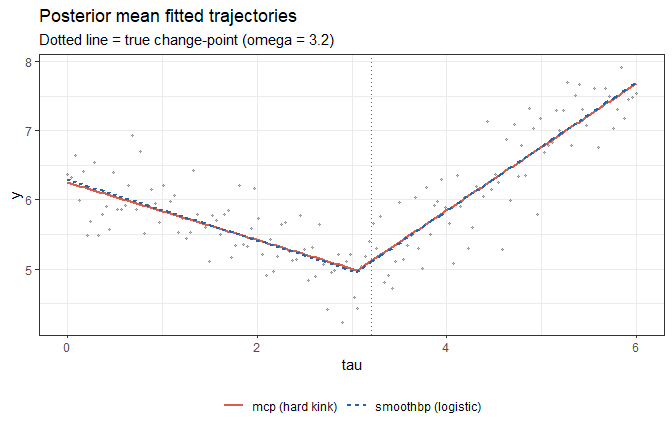

```r
tau_grid <- seq(0, 6, length.out = 200)

# smoothbp posterior mean trajectory
draws_sbp_mcp  <- posterior::as_draws_matrix(fit_sbp_mcp$draws)
b0_m   <- mean(draws_sbp_mcp[, "b0_(Intercept)"])
b1_m   <- mean(draws_sbp_mcp[, "b1_(Intercept)"])
delta1_m <- mean(draws_sbp_mcp[, "delta1_(Intercept)"])
om_m   <- mean(draws_sbp_mcp[, "omega1_(Intercept)"])
rho_m  <- mean(draws_sbp_mcp[, "rho1_(Intercept)"])

sigmoid  <- function(x) 1 / (1 + exp(-x))
d_grid   <- tau_grid - om_m
mu_sbp   <- b0_m + b1_m * d_grid + delta1_m * d_grid * sigmoid(d_grid * rho_m)

# mcp posterior mean trajectory
cp_m    <- mcp_sum$mean[mcp_sum$name == "cp_1"]
int_m   <- mcp_sum$mean[mcp_sum$name == "int_1"]
t1_m    <- mcp_sum$mean[mcp_sum$name == "tau_1"]
t2_m    <- mcp_sum$mean[mcp_sum$name == "tau_2"]
mu_mcp  <- ifelse(tau_grid < cp_m,
                  int_m + t1_m * tau_grid,
                  int_m + t1_m * cp_m + t2_m * (tau_grid - cp_m))

traj_df <- data.frame(
  tau    = rep(tau_grid, 2),
  mu     = c(mu_sbp, mu_mcp),
  model  = rep(c("smoothbp (logistic)", "mcp (hard kink)"), each = 200)
)

ggplot() +
  geom_point(aes(tau, y), data = dat_mcp_plain, alpha = 0.25, size = 0.8) +
  geom_line(aes(tau, mu, colour = model, linetype = model),
            data = traj_df, linewidth = 0.9) +
  geom_vline(xintercept = 3.2, linetype = "dotted", colour = "grey40") +
  scale_colour_manual(values = c("smoothbp (logistic)" = "#2166ac",
                                 "mcp (hard kink)"     = "#d6604d")) +
  labs(title    = "Posterior mean fitted trajectories",
       subtitle = "Dotted line = true change-point (omega = 3.2)",
       x = "tau", y = "y", colour = NULL, linetype = NULL) +
  theme_bw() +
  theme(legend.position = "bottom")
```

## Timing and ESS comparison

```r
# smoothbp ESS on omega
sbp_ess_mcp <- posterior::summarise_draws(
  fit_sbp_mcp$draws[,, c("omega1_(Intercept)", "b1_(Intercept)",
                          "delta1_(Intercept)", "sigma")],
  ess_bulk = posterior::ess_bulk
) |>
  dplyr::mutate(ess_per_sec = ess_bulk / time_sbp_mcp,
                package = "smoothbp")

# mcp ESS — extract draws from mcp object
# mcp stores posterior draws as a coda::mcmc.list in $mcmc_post
mcp_draws <- posterior::as_draws_array(fit_mcp$mcmc_post)
mcp_ess_draws <- posterior::summarise_draws(
  mcp_draws[, , c("cp_1", "tau_1", "sigma_1")],
  ess_bulk = posterior::ess_bulk
)
mcp_ess_raw <- setNames(mcp_ess_draws$ess_bulk, mcp_ess_draws$variable)

data.frame(
  parameter   = c("omega / cp_1", "b1 / time_1", "sigma"),
  sbp_ess_s   = round(sbp_ess_mcp$ess_per_sec[
    match(c("omega1_(Intercept)", "b1_(Intercept)", "sigma"),
          sbp_ess_mcp$variable)], 1),
  mcp_ess_s   = round(c(mcp_ess_raw["cp_1"],
                         mcp_ess_raw["tau_1"],
                         mcp_ess_raw["sigma_1"]) / time_mcp, 1)
) |>
  knitr::kable(caption = "ESS/second: smoothbp vs mcp.
                          Higher is better.")
```

ESS/second: smoothbp vs mcp. Higher is better.

|  | parameter | sbp_ess_s | mcp_ess_s |
| --- | --- | --- | --- |
| cp_1 | omega / cp_1 | 40.8 | 128.5 |
| tau_1 | b1 / time_1 | 116.7 | 73.4 |
| sigma_1 | sigma | 358.8 | 1472.9 |

```r
data.frame(
  package      = c("smoothbp", "mcp (JAGS)"),
  wall_clock_s = round(c(time_sbp_mcp, time_mcp), 1),
  speedup       = c(sprintf("%.0fx faster", time_mcp / time_sbp_mcp), "reference")
) |>
  knitr::kable(col.names = c("Package", "Wall-clock (s)", "Relative speed"),
               caption   = "Scenario 3 wall-clock time. Single-group, n = 150.")
```

Scenario 3 wall-clock time. Single-group, n = 150.

| Package | Wall-clock (s) | Relative speed |
| --- | --- | --- |
| smoothbp | 9.8 | 0x faster |
| mcp (JAGS) | 3.0 | reference |

## What to look for

If both samplers have converged, the marginal posteriors overlay almost exactly, the means agree to within Monte Carlo error (`delta_mean_pct` should be a fraction of a per cent for well-mixed parameters), and the credible intervals are within sampling variability of each other.

If you remove the `ub = max(dat$tau)` bound or the `init_fun`, you will likely see the brms posterior on `omega` and `b2` go bimodal: one cluster near the truth, and a second cluster in the unidentifiable region with `omega > max(tau)` and `b2` pinned at a ridiculous value matching the right-edge slope. That is a sampler-mixing artefact, not a real feature of the posterior, and worth demonstrating in your own analyses before trusting results from change-point models that allow `omega` to escape the data range.

A note on smoothbp’s robustness: smoothbp initialises every chain near the prior mean, which keeps it out of the degenerate region by construction. That is excellent in practice when the user has a sensible prior on `omega`, and is the typical case. It also means that on a problem where the posterior is genuinely multimodal, the chains may all converge to whichever mode is closest to the prior mean and fail to explore the others. If you suspect multimodality, fit with deliberately overdispersed initial values by varying the prior across runs.

# Scenario 4: Multi-breakpoint model

This scenario validates the new multi-breakpoint architecture by simulating data with **two true change-points** and fitting both smoothbp and brms. If the two samplers agree — i.e., marginal posteriors overlap — we have strong evidence that the implementation is correct.

## Simulate two-breakpoint data

```r
set.seed(9801)
n  <- 300
tau <- seq(0, 12, length.out = n)

# True model: two breakpoints
om1_true    <-  3.5;  rho1_true <- 5.0;  delta1_true <- -1.2
om2_true    <-  8.0;  rho2_true <- 4.0;  delta2_true <-  1.8
b0_true     <-  5.0;  b1_true   <-  0.3;  sigma_true  <-  0.3

d1  <- tau - om1_true;  s1 <- plogis(d1 * rho1_true)
d2  <- tau - om2_true;  s2 <- plogis(d2 * rho2_true)
mu  <- b0_true + b1_true * (tau - om1_true) +
       delta1_true * d1 * s1 + delta2_true * d2 * s2
y   <- mu + rnorm(n, sd = sigma_true)
dat_multi <- data.frame(y = y, tau = tau)

cat(sprintf("True: b0=%.1f b1=%.1f delta1=%.1f omega1=%.1f delta2=%.1f omega2=%.1f sigma=%.1f\n",
            b0_true, b1_true, delta1_true, om1_true, delta2_true, om2_true, sigma_true))
```

```
#> True: b0=5.0 b1=0.3 delta1=-1.2 omega1=3.5 delta2=1.8 omega2=8.0 sigma=0.3
```

## Fit with smoothbp

```r
t0 <- Sys.time()
fit_sbp_multi <- smoothbp(
  formula = y ~ tau,
  b0      = ~ 1,
  b1      = ~ 1,
  deltas  = list(~ 1, ~ 1),
  omega   = list(~ 1, ~ 1),
  rho     = list(~ 1, ~ 1),
  data    = dat_multi,
  priors  = smoothbp_priors(
    b0     = prior_normal(0, 10),
    b1     = prior_normal(0, 2),
    omega  = list(
      prior_normal(3.5, 2, lb = 0, ub = 6),
      prior_normal(8.0, 2, lb = 4, ub = max(dat_multi$tau))
    ),
    rho    = list(prior_normal(4, 2, lb = 0),
                  prior_normal(4, 2, lb = 0))
  ),
  chains = 4L, iter = 2000L, warmup = 1000L,
  seed = 9801L, .verbose = FALSE
)
time_sbp_multi <- as.numeric(difftime(Sys.time(), t0, units = "secs"))
cat(sprintf("smoothbp: %.1f s\n", time_sbp_multi))
```

```
#> smoothbp: 58.2 s
```

## Fit with brms (Stan / NUTS)

```r
suppressPackageStartupMessages(library(brms))

# Two-breakpoint non-linear formula for brms
bf_multi <- brms::bf(
  y ~ b0 + b1 * (tau - om1) +
        d1 * (tau - om1) / (1 + exp(-(tau - om1) * rho1)) +
        d2 * (tau - om2) / (1 + exp(-(tau - om2) * rho2)),
  b0 ~ 1, b1 ~ 1,
  d1 ~ 1, om1 ~ 1, rho1 ~ 1,
  d2 ~ 1, om2 ~ 1, rho2 ~ 1,
  nl = TRUE
)

priors_brms_multi <- c(
  brms::prior(normal(0, 10),  nlpar = "b0"),
  brms::prior(normal(0, 2),   nlpar = "b1"),
  brms::prior(normal(0, 2),   nlpar = "d1"),
  brms::prior_string("normal(3.5, 2)", nlpar = "om1", lb = 0, ub = 6),
  brms::prior(normal(4, 2),   nlpar = "rho1", lb = 0),
  brms::prior(normal(0, 2),   nlpar = "d2"),
  brms::prior_string("normal(8.0, 2)", nlpar = "om2", lb = 4, ub = 12),
  brms::prior(normal(4, 2),   nlpar = "rho2", lb = 0)
)

init_multi <- function() list(
  b_b0   = array(rnorm(1, 5, 0.5)),
  b_b1   = array(rnorm(1, 0.3, 0.1)),
  b_d1   = array(rnorm(1, -1, 0.3)),
  b_om1  = array(rnorm(1, 3.5, 0.3)),
  b_rho1 = array(rnorm(1, 5, 0.5)),
  b_d2   = array(rnorm(1, 1.5, 0.3)),
  b_om2  = array(rnorm(1, 8, 0.3)),
  b_rho2 = array(rnorm(1, 4, 0.5))
)

t0 <- Sys.time()
fit_brms_multi <- brms::brm(
  bf_multi,
  data    = dat_multi,
  prior   = priors_brms_multi,
  chains  = 4, iter = 2000, warmup = 1000,
  seed    = 9801, refresh = 0,
  init    = init_multi,
  control = list(adapt_delta = 0.95)
)
time_brms_multi <- as.numeric(difftime(Sys.time(), t0, units = "secs"))
```

## Compare posteriors

```r
sbp_names_multi <- c(
  "b0_(Intercept)", "b1_(Intercept)",
  "delta1_(Intercept)", "omega1_(Intercept)", "rho1_(Intercept)",
  "delta2_(Intercept)", "omega2_(Intercept)", "rho2_(Intercept)",
  "sigma"
)
brms_names_multi <- c(
  "b_b0_Intercept", "b_b1_Intercept",
  "b_d1_Intercept", "b_om1_Intercept", "b_rho1_Intercept",
  "b_d2_Intercept", "b_om2_Intercept", "b_rho2_Intercept",
  "sigma"
)
true_vals_multi <- c(b0_true, b1_true,
                     delta1_true, om1_true, rho1_true,
                     delta2_true, om2_true, rho2_true,
                     sigma_true)

sbp_draws_multi  <- posterior::as_draws_df(fit_sbp_multi$draws)[, sbp_names_multi]
brms_draws_multi <- as.data.frame(
  posterior::as_draws_df(fit_brms_multi)
)[, brms_names_multi]
colnames(brms_draws_multi) <- sbp_names_multi

draws_long_multi <- dplyr::bind_rows(
  tidyr::pivot_longer(sbp_draws_multi, cols = dplyr::everything(),
                      names_to = "parameter", values_to = "value") |>
    dplyr::mutate(package = "smoothbp"),
  tidyr::pivot_longer(brms_draws_multi, cols = dplyr::everything(),
                      names_to = "parameter", values_to = "value") |>
    dplyr::mutate(package = "brms")
)

draws_long_multi |>
  dplyr::group_by(parameter, package) |>
  dplyr::summarise(mean = mean(value), sd = sd(value),
                   q025 = quantile(value, 0.025),
                   q975 = quantile(value, 0.975), .groups = "drop") |>
  tidyr::pivot_wider(names_from = package,
                     values_from = c(mean, sd, q025, q975),
                     names_glue = "{package}_{.value}") |>
  dplyr::mutate(
    truth          = true_vals_multi[match(parameter, sbp_names_multi)],
    delta_mean_pct = 100 * abs(smoothbp_mean - brms_mean) /
                       (abs(brms_mean) + 1e-8)
  ) |>
  knitr::kable(digits = 3,
               caption = "Scenario 4: two-breakpoint smoothbp vs brms.")
```

Scenario 4: two-breakpoint smoothbp vs brms.

| parameter | brms_mean | smoothbp_mean | brms_sd | smoothbp_sd | brms_q025 | smoothbp_q025 | brms_q975 | smoothbp_q975 | truth | delta_mean_pct |
| --- | --- | --- | --- | --- | --- | --- | --- | --- | --- | --- |
| b0_(Intercept) | 4.923 | 4.921 | 0.056 | 0.057 | 4.807 | 4.805 | 5.031 | 5.032 | 5.0 | 0.049 |
| b1_(Intercept) | 0.257 | 0.255 | 0.031 | 0.031 | 0.196 | 0.193 | 0.319 | 0.317 | 0.3 | 1.034 |
| delta1_(Intercept) | -1.161 | -1.161 | 0.042 | 0.044 | -1.243 | -1.246 | -1.080 | -1.076 | -1.2 | 0.004 |
| delta2_(Intercept) | 1.801 | 1.802 | 0.043 | 0.045 | 1.712 | 1.711 | 1.880 | 1.887 | 1.8 | 0.039 |
| omega1_(Intercept) | 3.567 | 3.577 | 0.074 | 0.073 | 3.424 | 3.441 | 3.714 | 3.722 | 3.5 | 0.272 |
| omega2_(Intercept) | 7.966 | 7.960 | 0.048 | 0.049 | 7.874 | 7.864 | 8.063 | 8.058 | 8.0 | 0.081 |
| rho1_(Intercept) | 4.341 | 4.414 | 1.502 | 1.538 | 2.040 | 2.050 | 7.782 | 7.835 | 5.0 | 1.682 |
| rho2_(Intercept) | 4.370 | 4.366 | 1.550 | 1.578 | 2.040 | 2.015 | 7.789 | 7.901 | 4.0 | 0.083 |
| sigma | 0.298 | 0.308 | 0.012 | 0.013 | 0.275 | 0.285 | 0.324 | 0.334 | 0.3 | 3.194 |

## Overlaid marginal posteriors — the key validation

The densities from smoothbp (blue) and brms (red) should overlap almost exactly if both samplers are targeting the same posterior. Dashed vertical lines mark the true data-generating values.

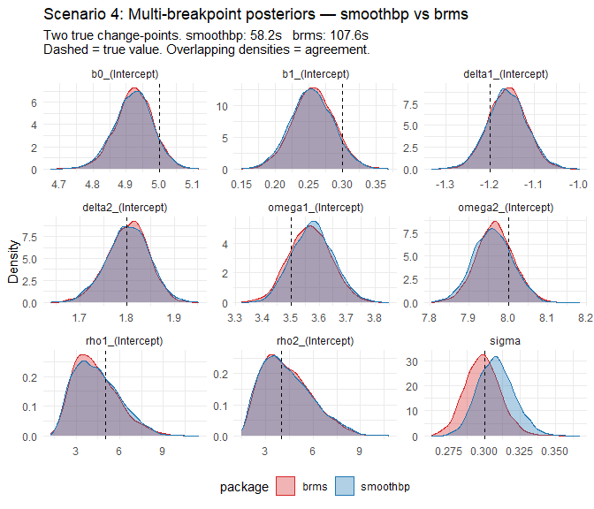

```r
true_df_multi <- data.frame(
  parameter  = sbp_names_multi,
  true_value = true_vals_multi
)

ggplot(draws_long_multi, aes(x = value, fill = package, colour = package)) +
  geom_density(alpha = 0.35, linewidth = 0.6) +
  geom_vline(data = true_df_multi,
             aes(xintercept = true_value),
             linetype = "dashed", linewidth = 0.5, colour = "black") +
  facet_wrap(~ parameter, scales = "free", ncol = 3) +
  scale_fill_manual(values   = c(smoothbp = "#1f77b4", brms = "#d62728")) +
  scale_colour_manual(values = c(smoothbp = "#1f77b4", brms = "#d62728")) +
  labs(
    title    = "Scenario 4: Multi-breakpoint posteriors — smoothbp vs brms",
    subtitle = sprintf(
      "Two true change-points. smoothbp: %.1fs   brms: %.1fs\nDashed = true value. Overlapping densities = agreement.",
      time_sbp_multi, time_brms_multi
    ),
    x = NULL, y = "Density"
  ) +
  theme_minimal(base_size = 11) +
  theme(legend.position = "bottom")
```

## What to look for

- **Density overlap**: the blue (smoothbp) and red (brms) curves should be nearly indistinguishable for every parameter. Meaningful separation would indicate a bug in one of the implementations.
- **True value coverage**: dashed lines should fall inside or very near the high-density region of both posteriors.
- **Timing**: smoothbp’s Rust sampler should be substantially faster than brms/Stan, especially at larger $n$.

```r
ess_sbp_multi <- posterior::summarise_draws(
  fit_sbp_multi$draws[, , sbp_names_multi], ess_bulk = posterior::ess_bulk
) |>
  dplyr::transmute(parameter = variable,
                   smoothbp_ess_per_sec = ess_bulk / time_sbp_multi)

ess_brms_multi <- posterior::summarise_draws(
  posterior::as_draws_df(fit_brms_multi), ess_bulk = posterior::ess_bulk
) |>
  dplyr::filter(variable %in% brms_names_multi) |>
  dplyr::mutate(parameter = sbp_names_multi[match(variable, brms_names_multi)]) |>
  dplyr::transmute(parameter, brms_ess_per_sec = ess_bulk / time_brms_multi)

dplyr::full_join(ess_sbp_multi, ess_brms_multi, by = "parameter") |>
  knitr::kable(digits = 1,
               caption = "ESS/second: smoothbp vs brms (two-breakpoint model).")
```

ESS/second: smoothbp vs brms (two-breakpoint model).

| parameter | smoothbp_ess_per_sec | brms_ess_per_sec |
| --- | --- | --- |
| b0_(Intercept) | 14.4 | 13.8 |
| b1_(Intercept) | 9.5 | 15.0 |
| delta1_(Intercept) | 16.0 | 13.1 |
| omega1_(Intercept) | 2.8 | 21.2 |
| rho1_(Intercept) | 24.7 | 21.5 |
| delta2_(Intercept) | 10.0 | 18.8 |
| omega2_(Intercept) | 2.9 | 27.0 |
| rho2_(Intercept) | 7.9 | 20.9 |
| sigma | 66.9 | 30.8 |

```r
data.frame(
  package      = c("smoothbp", "brms (Stan/NUTS)"),
  wall_clock_s = round(c(time_sbp_multi, time_brms_multi), 1),
  speedup       = c(sprintf("%.0fx faster", time_brms_multi / time_sbp_multi), "reference")
) |>
  knitr::kable(col.names = c("Package", "Wall-clock (s)", "Relative speed"),
               caption   = "Scenario 4 wall-clock time. Two-breakpoint model (single group, fixed effects).")
```

Scenario 4 wall-clock time. Two-breakpoint model (single group, fixed effects).

| Package | Wall-clock (s) | Relative speed |
| --- | --- | --- |
| smoothbp | 58.2 | 2x faster |
| brms (Stan/NUTS) | 107.6 | reference |